# Lab_1

Markin Nikita

2026-10-08

# 1. Цель и постановка задачи

Цель - освоить импорт и проверку анкет в R, восстановить распределения ответов, оценить восприятие инфляции, среднедушевой доход и потребительские настроения. Расчеты выполнены по индивидуальному файлу «Маркин.Никита.Алексеевич_Б24-902_Вар95.xlsx». В каждой из 2000 строк находится отдельная синтетическая анкета; веса наблюдений не заданы, поэтому все строки имеют одинаковый вес.

Учебный расчет относится к сентябрю 2026 года. Он не является результатом опроса Банка России. Сравнение с опубликованным августом допускается только как учебное сопоставление разных источников. Расчеты выполнены без промежуточного округления; доли в частотных таблицах округлены до целого процента, итоговые показатели - до одного десятичного знака. Квартили рассчитаны функцией `quantile(..., type = 7)`.

**Источник исторической части.** Опубликованные значения января–августа 2026 года перенесены из предоставленного отчета инФОМ за август 2026 года (волна 162): с. 10, рис. 6 — две инфляционные медианы; с. 14, рис. 12 — ИТС, ИПО и ИПН. Дата получения и проверки PDF — 18.10.2026. Использованы числовые подписи к точкам с точностью публикации: один десятичный знак для инфляции и целые пункты для индексов. Длина линий не измерялась, дополнительные знаки не восстанавливались. Учебные сентябрьские точки выделены отдельно и не соединены с официальными линиями.

# 2. Структура и качество исходного файла

Импорт выполнен через `openxlsx::read.xlsx`, лист «Анкеты». Объект `Data_OG` сохраняет исходную таблицу; очистка и новые переменные создаются в копии `Data`. Исходный XLSX не изменяется. Некорректные значения исключаются только из расчетов соответствующей переменной; целые анкеты не удаляются.

В файле 21 столбец: ID, Q1–Q13 и семь из восьми ожидаемых характеристик. **Отсутствует «Категория дохода на одного члена семьи»**; это затрагивает все 2000 анкет, но не препятствует расчету дохода по Q12 и Q13. Вместо отсутствующей характеристики для группового анализа применены пять квантильных групп рассчитанного дохода - учебное допущение, прямо предусмотренное индивидуальным запросом.

Размер листа в служебном XML XLSX указан как A1, хотя фактически заполнены 2001 строка с заголовком и 21 столбец. Кроме того, в архиве отсутствует объект рисунка, на который есть ссылка. Это технические особенности контейнера: выбранный `openxlsx` считал все анкеты без изменения файла; анализ рисунков книги не требуется.

В таблице 1 приведены структурные и построчные проверки. Числа разных проверок не складываются: одна строка может относиться к нескольким проверкам. Отсутствующий столбец учтен отдельно от строк с некорректным значением.

Таблица 1. Проверка структуры, значений и логики

| Проверка | Число |
| --- | --- |
| Отсутствующие столбцы (единица - столбцы) | 1 |
| Отсутствующая характеристика дохода (затронуто анкет) | 2000 |
| Пустой ID | 0 |
| Строки с повторяющимся непустым ID | 0 |
| Недопустимая категория хотя бы в одном поле (строки) | 0 |
| Q12: пропуск, нечисловое, нецелое или неположительное | 0 |
| Q4 пусто, хотя поле требуется | 0 |
| Q4 заполнено, хотя поле не задавалось | 0 |
| Q6 пусто, хотя поле требуется | 0 |
| Q6 заполнено, хотя поле не задавалось | 0 |
| Тип предприятия работодателя пусто, хотя поле требуется | 0 |
| Тип предприятия работодателя заполнено, хотя поле не задавалось | 0 |

Таблица 2. Число пригодных наблюдений по показателям

| Показатель | N |
| --- | --- |
| Пол | 2000 |
| Возраст | 2000 |
| Образование | 2000 |
| Род занятий | 2000 |
| Тип предприятия работодателя | 1161 |
| Тип расселения | 2000 |
| Самооценка материального положения семьи | 2000 |
| Q1 | 2000 |
| Q2 | 2000 |
| Q3 | 2000 |
| Q4 | 1862 |
| Q5 | 2000 |
| Q6 | 1697 |
| Q7 | 2000 |
| Q8 | 2000 |
| Q9 | 2000 |
| Q10 | 2000 |
| Q11 | 2000 |
| Q13 | 2000 |
| Q12 | 2000 |
| infl_obs | 1445 |
| infl_exp | 1313 |
| Доход на человека | 1613 |

Таблица 3. Основания частотных таблиц, технические и недопустимые ответы

| Поле | Основание | Пригодно | Тех. пропуск | Недопустимо |
| --- | --- | --- | --- | --- |
| Пол | 2000 | 2000 | 0 | 0 |
| Возраст | 2000 | 2000 | 0 | 0 |
| Образование | 2000 | 2000 | 0 | 0 |
| Род занятий | 2000 | 2000 | 0 | 0 |
| Тип предприятия работодателя | 1161 | 1161 | 0 | 0 |
| Тип расселения | 2000 | 2000 | 0 | 0 |
| Самооценка материального положения семьи | 2000 | 2000 | 0 | 0 |
| Q1 | 2000 | 2000 | 0 | 0 |
| Q2 | 2000 | 2000 | 0 | 0 |
| Q3 | 2000 | 2000 | 0 | 0 |
| Q4 | 1862 | 1862 | 0 | 0 |
| Q5 | 2000 | 2000 | 0 | 0 |
| Q6 | 1697 | 1697 | 0 | 0 |
| Q7 | 2000 | 2000 | 0 | 0 |
| Q8 | 2000 | 2000 | 0 | 0 |
| Q9 | 2000 | 2000 | 0 | 0 |
| Q10 | 2000 | 2000 | 0 | 0 |
| Q11 | 2000 | 2000 | 0 | 0 |
| Q13 | 2000 | 2000 | 0 | 0 |

Таблица 4. Структурные пропуски и согласованность условий задавания

| Поле | Структ. пропуск | Логич. конфликт | Условие неизвестно |
| --- | --- | --- | --- |
| Пол | 0 | 0 | 0 |
| Возраст | 0 | 0 | 0 |
| Образование | 0 | 0 | 0 |
| Род занятий | 0 | 0 | 0 |
| Тип предприятия работодателя | 0 | 0 | 0 |
| Тип расселения | 0 | 0 | 0 |
| Самооценка материального положения семьи | 0 | 0 | 0 |
| Q1 | 0 | 0 | 0 |
| Q2 | 0 | 0 | 0 |
| Q3 | 0 | 0 | 0 |
| Q4 | 138 | 0 | 0 |
| Q5 | 0 | 0 | 0 |
| Q6 | 303 | 0 | 0 |
| Q7 | 0 | 0 | 0 |
| Q8 | 0 | 0 | 0 |
| Q9 | 0 | 0 | 0 |
| Q10 | 0 | 0 | 0 |
| Q11 | 0 | 0 | 0 |
| Q13 | 0 | 0 | 0 |

Таблица 2 показывает основания расчетов. В таблицах 3–4 технический пропуск означает пустую ячейку в поле, которое должно быть заполнено. Структурный пропуск - отсутствие ответа, потому что вопрос не задавался. Ответ «затрудняюсь ответить» является допустимой категорией, а не техническим пропуском. Q4 задавался при первых трех ответах Q3, Q6 - при первых трех ответах Q5; тип работодателя требовался только для работающих по найму. Пустоты этих условных полей согласуются с логикой анкеты. Неизвестное условие задавания не смешивается с достоверно незаданным вопросом.

# 3. Абсолютные частоты и доли

Для категории j доля определяется формулой

$$p_j =
\frac{n_j}{N_j}\cdot100\%.$$

Для вопросов всем респондентам основание - число допустимых ответов, включая «затрудняюсь» и «отказ», но без технических пропусков. Для Q4 и Q6 основание - все респонденты, которым вопрос задавался; технические пропуски при их наличии также видны в аудите. Для типа работодателя приводится распределение среди работающих по найму с допустимым ответом. В дополнительных таблицах Q4/Q6 знаменатель - вся выборка, 2000 анкет. Сумма округленных долей может отличаться от 100%; нулевую частоту следует отличать от малой ненулевой частоты, округленной до 0%.

Ниже последовательно приведены все допустимые категории, включая категории с нулевой частотой; их порядок соответствует словарю анкеты. Снижение цен в Q3 показано отдельной нулевой категорией, хотя фактически таких ответов в варианте нет. Отсутствующую восьмую характеристику нельзя восстановить из пустого столбца: ее исходные частоты неизвестны, а расчетные группы показаны в разделе 8.

Таблица 5. Q1: частоты и доли; основание N = 2000

| Категория | n | Доля, % |
| --- | --- | --- |
| выросли очень сильно | 927 | 46 |
| выросли умеренно | 702 | 35 |
| выросли незначительно | 204 | 10 |
| не изменились | 71 | 4 |
| снизились | 8 | 0 |
| затрудняюсь ответить | 88 | 4 |

Таблица 6. Q2: частоты и доли; основание N = 2000

| Категория | n | Доля, % |
| --- | --- | --- |
| вырастут очень сильно | 408 | 20 |
| вырастут умеренно | 868 | 43 |
| вырастут незначительно | 283 | 14 |
| не изменятся | 178 | 9 |
| снизятся | 18 | 1 |
| затрудняюсь ответить | 245 | 12 |

Таблица 7. Q3: частоты и доли; основание N = 2000

| Категория | n | Доля, % |
| --- | --- | --- |
| росли быстрее, чем раньше | 1130 | 56 |
| росли так же, как и раньше | 625 | 31 |
| росли медленнее, чем раньше | 107 | 5 |
| остались на прежнем уровне / не изменились | 23 | 1 |
| снижались | 0 | 0 |
| затрудняюсь ответить | 115 | 6 |

Таблица 8. Q4: частоты и доли; основание N = 1862

| Категория | n | Доля, % |
| --- | --- | --- |
| на 2% и менее | 48 | 3 |
| на 3–5% | 169 | 9 |
| на 6–8% | 134 | 7 |
| на 9–12% | 271 | 15 |
| на 13–16% | 158 | 8 |
| на 17–20% | 185 | 10 |
| на 21–25% | 104 | 6 |
| на 26–30% | 156 | 8 |
| на 31–40% | 65 | 3 |
| на 41–50% | 60 | 3 |
| на 51% и более | 72 | 4 |
| затрудняюсь ответить | 440 | 24 |

Таблица 9. Q5: частоты и доли; основание N = 2000

| Категория | n | Доля, % |
| --- | --- | --- |
| будут расти быстрее, чем сейчас | 530 | 26 |
| будут расти так же, как и сейчас | 1045 | 52 |
| будут расти медленнее, чем сейчас | 122 | 6 |
| останутся на нынешнем уровне / не изменятся | 54 | 3 |
| будут снижаться | 18 | 1 |
| затрудняюсь ответить | 231 | 12 |

Таблица 10. Q6: частоты и доли; основание N = 1697

| Категория | n | Доля, % |
| --- | --- | --- |
| на 2% и менее | 48 | 3 |
| на 3–5% | 118 | 7 |
| на 6–8% | 149 | 9 |
| на 9–12% | 241 | 14 |
| на 13–16% | 123 | 7 |
| на 17–20% | 177 | 10 |
| на 21–25% | 94 | 6 |
| на 26–30% | 110 | 6 |
| на 31–40% | 64 | 4 |
| на 41–50% | 42 | 2 |
| на 51% и более | 75 | 4 |
| затрудняюсь ответить | 456 | 27 |

Таблица 11. Q7: частоты и доли; основание N = 2000

| Категория | n | Доля, % |
| --- | --- | --- |
| улучшилось | 241 | 12 |
| осталось без изменений | 1008 | 50 |
| ухудшилось | 713 | 36 |
| затрудняюсь ответить | 38 | 2 |

Таблица 12. Q8: частоты и доли; основание N = 2000

| Категория | n | Доля, % |
| --- | --- | --- |
| улучшится | 445 | 22 |
| останется без изменений | 727 | 36 |
| ухудшится | 463 | 23 |
| затрудняюсь ответить | 365 | 18 |

Таблица 13. Q9: частоты и доли; основание N = 2000

| Категория | n | Доля, % |
| --- | --- | --- |
| хорошим | 212 | 11 |
| хорошим, но не во всём | 368 | 18 |
| не хорошим, но и не плохим | 498 | 25 |
| плохим, но не во всём | 270 | 14 |
| плохим | 440 | 22 |
| затрудняюсь ответить | 212 | 11 |

Таблица 14. Q10: частоты и доли; основание N = 2000

| Категория | n | Доля, % |
| --- | --- | --- |
| хорошим | 357 | 18 |
| не хорошим, но и не плохим | 666 | 33 |
| плохим | 477 | 24 |
| затрудняюсь ответить | 500 | 25 |

Таблица 15. Q11: частоты и доли; основание N = 2000

| Категория | n | Доля, % |
| --- | --- | --- |
| хорошее | 399 | 20 |
| не хорошее, но и не плохое | 772 | 39 |
| плохое | 607 | 30 |
| затрудняюсь ответить | 222 | 11 |

Таблица 16. Q13: частоты и доли; основание N = 2000

| Категория | n | Доля, % |
| --- | --- | --- |
| 10 000 руб. и менее | 23 | 1 |
| 10 001 – 15 000 руб. | 17 | 1 |
| 15 001 – 20 000 руб. | 66 | 3 |
| 20 001 – 25 000 руб. | 67 | 3 |
| 25 001 – 30 000 руб. | 107 | 5 |
| 30 001 – 40 000 руб. | 192 | 10 |
| 40 001 – 50 000 руб. | 148 | 7 |
| 50 001 – 60 000 руб. | 141 | 7 |
| 60 001 – 70 000 руб. | 125 | 6 |
| 70 001 – 80 000 руб. | 87 | 4 |
| 80 001 – 90 000 руб. | 69 | 3 |
| 90 001 – 100 000 руб. | 125 | 6 |
| 100 001 – 120 000 руб. | 141 | 7 |
| 120 001 – 150 000 руб. | 102 | 5 |
| свыше 150 000 руб. | 203 | 10 |
| не знаю, затрудняюсь ответить | 158 | 8 |
| отказ от ответа | 229 | 11 |

Таблица 17. Пол: частоты и доли; основание N = 2000

| Категория | n | Доля, % |
| --- | --- | --- |
| женщины | 1102 | 55 |
| мужчины | 898 | 45 |

Таблица 18. Возраст: частоты и доли; основание N = 2000

| Категория | n | Доля, % |
| --- | --- | --- |
| 18–30 лет | 405 | 20 |
| 31–45 лет | 537 | 27 |
| 46–60 лет | 561 | 28 |
| старше 60 лет | 497 | 25 |

Таблица 19. Образование: частоты и доли; основание N = 2000

| Категория | n | Доля, % |
| --- | --- | --- |
| высшее | 642 | 32 |
| ниже среднего | 87 | 4 |
| среднее общее | 593 | 30 |
| среднее специальное | 678 | 34 |

Таблица 20. Род занятий: частоты и доли; основание N = 2000

| Категория | n | Доля, % |
| --- | --- | --- |
| не работают и не ищут работу | 96 | 5 |
| не работают, но ищут работу | 78 | 4 |
| неработающие пенсионеры | 470 | 24 |
| работающие по найму | 1161 | 58 |
| самозанятые | 195 | 10 |

Таблица 21. Тип предприятия работодателя: частоты и доли; основание N = 1161

| Категория | n | Доля, % |
| --- | --- | --- |
| государственное, с госучастием | 499 | 43 |
| частное, НКО | 662 | 57 |

Таблица 22. Тип расселения: частоты и доли; основание N = 2000

| Категория | n | Доля, % |
| --- | --- | --- |
| Городское | 1412 | 71 |
| Сельское | 588 | 29 |

Таблица 23. Самооценка материального положения семьи: частоты и доли; основание N = 2000

| Категория | n | Доля, % |
| --- | --- | --- |
| денег не хватает на питание | 116 | 6 |
| на питание хватает, на одежду – нет | 402 | 20 |
| на одежду хватает, на крупную бытовую технику – нет | 682 | 34 |
| на бытовую технику хватает, на автомобиль – нет | 479 | 24 |
| на автомобиль хватает | 321 | 16 |

Таблица 24. Q4: доли от всей выборки, N = 2000

| Категория | n | Доля от всех, % |
| --- | --- | --- |
| на 2% и менее | 48 | 2 |
| на 3–5% | 169 | 8 |
| на 6–8% | 134 | 7 |
| на 9–12% | 271 | 14 |
| на 13–16% | 158 | 8 |
| на 17–20% | 185 | 9 |
| на 21–25% | 104 | 5 |
| на 26–30% | 156 | 8 |
| на 31–40% | 65 | 3 |
| на 41–50% | 60 | 3 |
| на 51% и более | 72 | 4 |
| затрудняюсь ответить | 440 | 22 |
| Технический пропуск | 0 | 0 |
| Недопустимый ответ | 0 | 0 |
| Вопрос не задавался | 138 | 7 |
| Условие задавания неизвестно | 0 | 0 |

Таблица 25. Q6: доли от всей выборки, N = 2000

| Категория | n | Доля от всех, % |
| --- | --- | --- |
| на 2% и менее | 48 | 2 |
| на 3–5% | 118 | 6 |
| на 6–8% | 149 | 7 |
| на 9–12% | 241 | 12 |
| на 13–16% | 123 | 6 |
| на 17–20% | 177 | 9 |
| на 21–25% | 94 | 5 |
| на 26–30% | 110 | 6 |
| на 31–40% | 64 | 3 |
| на 41–50% | 42 | 2 |
| на 51% и более | 75 | 4 |
| затрудняюсь ответить | 456 | 23 |
| Технический пропуск | 0 | 0 |
| Недопустимый ответ | 0 | 0 |
| Вопрос не задавался | 303 | 15 |
| Условие задавания неизвестно | 0 | 0 |

Таблица 26. Q12: описательные показатели размера семьи

| N | Минимум | Максимум | Среднее | Медиана |
| --- | --- | --- | --- | --- |
| 2000 | 1 | 6 | 2.7 | 2 |

Таблица 27. Q12: распределение числа членов семьи

| Членов семьи | n | Доля, % |
| --- | --- | --- |
| 1 | 381 | 19 |
| 2 | 646 | 32 |
| 3 | 481 | 24 |
| 4 | 284 | 14 |
| 5 | 149 | 7 |
| 6 | 59 | 3 |

Распределения Q1/Q2 и Q3/Q5 визуализированы на рисунках 1–2 в разделе 9. Слова «быстрее / так же / медленнее» характеризуют темп роста цен относительно прошлого периода; они не задают числовой уровень годовой инфляции.

# 4. Перекодировка и обычные медианы годовой инфляции

Переменная `infl_obs` получена из Q3/Q4, `infl_exp` - из Q5/Q6. При неизменных ценах используется 0, при снижении - условный код −5. При любом варианте роста берется интервал условного вопроса. «Росли медленнее» означает положительный рост, а не дефляцию. Неопределенный ответ в любом необходимом вопросе не входит в числовую медиану; Q1/Q2 в проценты годовых не переводятся.

В таблице перекодировки указаны все 13 кодов и непрерывные границы для интерполяции. Пропуск L или h означает, что границы категории не позволяют выполнить интерполяцию без дополнительного соглашения.

Таблица 28. Правила числовой перекодировки и интерполяционные границы

| Категория | Код, % | Нижняя граница L | Ширина h |
| --- | --- | --- | --- |
| Снижение (условный код) | -5.0 | нет данных | нет данных |
| Без изменения | 0.0 | нет данных | нет данных |
| на 2% и менее | 1.0 | нет данных | нет данных |
| на 3–5% | 4.0 | 2.5 | 3 |
| на 6–8% | 7.0 | 5.5 | 3 |
| на 9–12% | 10.5 | 8.5 | 4 |
| на 13–16% | 14.5 | 12.5 | 4 |
| на 17–20% | 18.5 | 16.5 | 4 |
| на 21–25% | 23.0 | 20.5 | 5 |
| на 26–30% | 28.0 | 25.5 | 5 |
| на 31–40% | 35.5 | 30.5 | 10 |
| на 41–50% | 45.5 | 40.5 | 10 |
| на 51% и более | 75.0 | нет данных | нет данных |

Таблица 29. Число ответов, обычные медианы, квартили и уточненные медианы, % годовых

| Показатель | N | Q1 | Медиана | Q3 | Уточненная |
| --- | --- | --- | --- | --- | --- |
| Наблюдаемая | 1445 | 7 | 14.5 | 23 | 14.5 |
| Ожидаемая | 1313 | 7 | 14.5 | 23 | 13.4 |

Сводные показатели приведены в таблице 29. Число пригодных наблюдений равно 1445 для наблюдаемой и 1313 для ожидаемой инфляции. Из числовых расчетов исключено соответственно 555 и 687 анкет. Это исключение содержательных неопределенных ответов, а не удаление всех таких строк из анализа. Обычные медианы обеих переменных равны 14,5% годовых; первые квартили - 7,0 и 7,0%, третьи - 23,0 и 23,0%. График частот всех кодов приведен на рисунке 3.

# 5. Уточненные медианы годовой инфляции

Категории упорядочены по возрастанию кода. По частотам n вычислена накопленная частота F. Медианная категория - первая, для которой F достигает N/2. Внутри закрытого интервала предполагается равномерное распределение ответов и используется линейная интерполяция:

$$\tilde{x}_{0.5}=L+h\frac{N/2-F_{prev}}{f}.$$

Здесь L - нижняя непрерывная граница, h - ширина медианного интервала, F_prev - число ответов до него, f - частота внутри него. Например, для ответа «13–16%» используются [12,5; 16,5) и ширина 4. Полученная оценка не является точным восстановлением ответов: исходное распределение внутри интервала неизвестно.

Таблица 30. Наблюдаемая инфляция: частоты n и накопленные частоты F

| Категория | Код | n | F |
| --- | --- | --- | --- |
| Снижение (условный код) | -5.0 | 0 | 0 |
| Без изменения | 0.0 | 23 | 23 |
| на 2% и менее | 1.0 | 48 | 71 |
| на 3–5% | 4.0 | 169 | 240 |
| на 6–8% | 7.0 | 134 | 374 |
| на 9–12% | 10.5 | 271 | 645 |
| на 13–16% | 14.5 | 158 | 803 |
| на 17–20% | 18.5 | 185 | 988 |
| на 21–25% | 23.0 | 104 | 1092 |
| на 26–30% | 28.0 | 156 | 1248 |
| на 31–40% | 35.5 | 65 | 1313 |
| на 41–50% | 45.5 | 60 | 1373 |
| на 51% и более | 75.0 | 72 | 1445 |

Таблица 31. Ожидаемая инфляция: частоты n и накопленные частоты F

| Категория | Код | n | F |
| --- | --- | --- | --- |
| Снижение (условный код) | -5.0 | 18 | 18 |
| Без изменения | 0.0 | 54 | 72 |
| на 2% и менее | 1.0 | 48 | 120 |
| на 3–5% | 4.0 | 118 | 238 |
| на 6–8% | 7.0 | 149 | 387 |
| на 9–12% | 10.5 | 241 | 628 |
| на 13–16% | 14.5 | 123 | 751 |
| на 17–20% | 18.5 | 177 | 928 |
| на 21–25% | 23.0 | 94 | 1022 |
| на 26–30% | 28.0 | 110 | 1132 |
| на 31–40% | 35.5 | 64 | 1196 |
| на 41–50% | 45.5 | 42 | 1238 |
| на 51% и более | 75.0 | 75 | 1313 |

**Наблюдаемая инфляция.** Медианная категория - на 13–16%; N = 1445, N/2 = 722,5, L = 12,5, h = 4,0, F_prev = 645, f = 158. Подстановка: $\tilde{x}_{0.5} = 12,5 + 4,0 \cdot (722,5 - 645)/158 = 14,4620$ % годовых.

**Ожидаемая инфляция.** Медианная категория - на 13–16%; N = 1313, N/2 = 656,5, L = 12,5, h = 4,0, F_prev = 628, f = 123. Подстановка: $\tilde{x}_{0.5} = 12,5 + 4,0 \cdot (656,5 - 628)/123 = 13,4268$ % годовых.

Накопленные частоты приведены в таблицах 30 и 31. В обоих случаях медианная категория - «13–16%». Обычная медиана 14,5% является серединой упорядоченных **кодов**. Уточненные медианы равны 14,5 и 13,4%: они различаются, хотя медианные коды совпадают. Это связано с разными частотами до и внутри медианной категории. На рисунке 3 обычная медиана обозначена одной линией, уточненная - другой.

Если медианная категория была бы −5, 0, «2% и менее» или «51% и более», код присваивался бы по методичке, но результат обязательно помечался бы как условное значение с неопределенной интерполяцией. Произвольные границы открытым категориям не назначаются. Примененный учебный алгоритм не воспроизводит полностью закрытую процедуру Банка России.

# 6. Среднедушевой доход

Сначала совокупный семейный доход Q13 заменен серединой интервала H; по соглашению методички используются 12 500, а не 12 500,5 руб. для категории 10 001–15 000 руб. Крайние категории заменены 7000 и 200 000 руб. «Не знаю» и «отказ» исключены только из числовой оценки дохода. Для каждой пригодной анкеты вычислено

$$y_i=\frac{H_i}{m_i}, \qquad
IQR=Q_3-Q_1,$$

где m_i - положительное целое число членов семьи из Q12. Деление производится для каждого респондента **до** расчета медианы. Медиана отношений не равна в общем случае отношению медиан. Расчет относится к респондентам и не взвешивается по числу членов семьи.

Таблица 32. Перекодировка Q13 в совокупный доход семьи

| Категория | Доход семьи, руб. |
| --- | --- |
| 10 000 руб. и менее | 7000 |
| 10 001 – 15 000 руб. | 12500 |
| 15 001 – 20 000 руб. | 17500 |
| 20 001 – 25 000 руб. | 22500 |
| 25 001 – 30 000 руб. | 27500 |
| 30 001 – 40 000 руб. | 35000 |
| 40 001 – 50 000 руб. | 45000 |
| 50 001 – 60 000 руб. | 55000 |
| 60 001 – 70 000 руб. | 65000 |
| 70 001 – 80 000 руб. | 75000 |
| 80 001 – 90 000 руб. | 85000 |
| 90 001 – 100 000 руб. | 95000 |
| 100 001 – 120 000 руб. | 110000 |
| 120 001 – 150 000 руб. | 135000 |
| свыше 150 000 руб. | 200000 |
| не знаю, затрудняюсь ответить | нет данных |
| отказ от ответа | нет данных |

Таблица 33. Описательные показатели дохода на человека, руб. в месяц

| N | Среднее | Медиана | Q1 | Q3 | IQR | Уточненная |
| --- | --- | --- | --- | --- | --- | --- |
| 1613 | 38675.8 | 27500 | 13750 | 47500 | 33750 | 26164.1 |

Таблица 34. Интервальный ряд дохода с шагом 5000 руб., частоты n и накопленные F

| Интервал | n | F |
| --- | --- | --- |
| [0,5e+03) | 47 | 47 |
| [5e+03,1e+04) | 178 | 225 |
| [1e+04,1.5e+04) | 183 | 408 |
| [1.5e+04,2e+04) | 217 | 625 |
| [2e+04,2.5e+04) | 151 | 776 |
| [2.5e+04,3e+04) | 131 | 907 |
| [3e+04,3.5e+04) | 77 | 984 |
| [3.5e+04,4e+04) | 98 | 1082 |
| [4e+04,4.5e+04) | 35 | 1117 |
| [4.5e+04,5e+04) | 93 | 1210 |
| [5e+04,5.5e+04) | 29 | 1239 |
| [5.5e+04,6e+04) | 64 | 1303 |
| [6e+04,6.5e+04) | 0 | 1303 |
| [6.5e+04,7e+04) | 122 | 1425 |
| [7e+04,7.5e+04) | 0 | 1425 |
| [7.5e+04,8e+04) | 16 | 1441 |
| [8e+04,8.5e+04) | 0 | 1441 |
| [8.5e+04,9e+04) | 10 | 1451 |
| [9e+04,9.5e+04) | 0 | 1451 |
| [9.5e+04,1e+05) | 18 | 1469 |
| [1e+05,1.05e+05) | 62 | 1531 |
| [1.05e+05,1.1e+05) | 0 | 1531 |
| [1.1e+05,1.15e+05) | 22 | 1553 |
| [1.15e+05,1.2e+05) | 0 | 1553 |
| [1.2e+05,1.25e+05) | 0 | 1553 |
| [1.25e+05,1.3e+05) | 0 | 1553 |
| [1.3e+05,1.35e+05) | 0 | 1553 |
| [1.35e+05,1.4e+05) | 20 | 1573 |
| [1.4e+05,1.45e+05) | 0 | 1573 |
| [1.45e+05,1.5e+05) | 0 | 1573 |
| [1.5e+05,1.55e+05) | 0 | 1573 |
| [1.55e+05,1.6e+05) | 0 | 1573 |
| [1.6e+05,1.65e+05) | 0 | 1573 |
| [1.65e+05,1.7e+05) | 0 | 1573 |
| [1.7e+05,1.75e+05) | 0 | 1573 |
| [1.75e+05,1.8e+05) | 0 | 1573 |
| [1.8e+05,1.85e+05) | 0 | 1573 |
| [1.85e+05,1.9e+05) | 0 | 1573 |
| [1.9e+05,1.95e+05) | 0 | 1573 |
| [1.95e+05,2e+05) | 0 | 1573 |
| [2e+05,2.05e+05] | 40 | 1613 |

Результаты расчетов дохода приведены в таблицах 32–34. Для группировки использованы полуинтервалы [a; b), начиная с нуля, с шагом 5000 руб.; последний интервал включает максимум. При максимуме, кратном 5000, добавляется следующий класс, чтобы сохранить единое правило левой замкнутости. Гистограмма на рисунке 4 использует те же границы, что и интервальный ряд.

Медианный интервал - [25000; 30000) руб. Подстановка в формулу:

$$\tilde{y}_{0.5}=25000+5000\frac{806.5-776}{131}=26164,1221\text{
руб.}.$$

Основание N = 1613, F_prev = 776, частота медианного интервала f = 131. Обычная медиана - 27500,0 руб., уточненная - 26164,1 руб.; различие вызвано группировкой и допущением о распределении внутри класса. Оценки чувствительны к условным кодам крайних доходных интервалов и к качеству Q12. На с. 20 (рис. 16) опубликована августовская медиана среднедушевого располагаемого дохода 27,3 тыс. руб., то есть 27300 руб. Обычная учебная медиана отличается от нее на +200,0 руб., уточненная — на -1135,9 руб. Прямое сопоставление ограничено различиями методик, состава и весов выборок; учебный показатель не является официальной оценкой дохода населения.

# 7. Потребительские индексы

## 7.1. Пять частных индексов

По Q7/Q8 положительными считаются «улучшилось / улучшится», отрицательными - «ухудшилось / ухудшится». Для Q9 положительны «хорошим» и «хорошим, но не во всём», отрицательны «плохим, но не во всём» и «плохим». Для Q10 положителен ответ «хорошим», отрицателен «плохим»; для Q11 - «хорошее» и «плохое». Прочие допустимые ответы не входят в числители. «Затрудняюсь ответить» входит в знаменатель каждого соответствующего индекса, технический пропуск - нет.

$$P_j=100\frac{n_j^+}{N_j},\qquad
M_j=100\frac{n_j^-}{N_j},\qquad I_j=100+P_j-M_j.$$

В таблице частных индексов P и M измерены в процентах, значение индекса - в пунктах. Теоретический диапазон индекса - 0–200; отметка 100 означает равенство положительных и отрицательных долей, а не долю 100%. Полные названия I1–I5 подписаны на рисунке 5.

Таблица 35. Частные индексы: числители, основания, доли и итоговые значения

| Индекс | Вопрос | n_pos | n_neg | N | P | M | Значение |
| --- | --- | --- | --- | --- | --- | --- | --- |
| I1 | Q7 | 241 | 713 | 2000 | 12.1 | 35.6 | 76.4 |
| I2 | Q8 | 445 | 463 | 2000 | 22.2 | 23.1 | 99.1 |
| I3 | Q9 | 580 | 710 | 2000 | 29.0 | 35.5 | 93.5 |
| I4 | Q10 | 357 | 477 | 2000 | 17.9 | 23.9 | 94.0 |
| I5 | Q11 | 399 | 607 | 2000 | 20.0 | 30.4 | 89.6 |

По таблице 35 все пять частных индексов ниже 100. Самый низкий показатель - I1 (76,4 пункта), характеризующий изменение материального положения за год. Ближе всех к равновесию находится I2 (99,1 пункта), то есть ожидания положения семьи. Этот вывод описывает только синтетический вариант.

## 7.2. Составные индексы

$$ИТС=\frac{I_1+I_5}{2},\qquad
ИПО=\frac{I_2+I_3+I_4}{3},$$

$$ИПН=\frac{I_1+I_2+I_3+I_4+I_5}{5}=\frac{2ИТС+3ИПО}{5}.$$

Таблица 36. Составные индексы и независимая проверка ИПН, пункты

| Индекс | Значение |
| --- | --- |
| ИТС | 83.0 |
| ИПО | 95.5 |
| ИПН | 90.5 |
| ИПН: проверочная формула | 90.5 |

Таблица 36 содержит итоговые индексы и проверку. Подстановка: ИТС = (76,4 + 89,6)/2 = 83,0; ИПО = (99,1 + 93,5 + 94,0)/3 = 95,5; ИПН = 90,5 пункта. По второй формуле без округления получено то же число; абсолютная разность результатов меньше 10⁻¹⁰. Простое среднее ИТС и ИПО не применяется: в них входят два и три частных индекса.

На рисунке 6 ИТС ниже ИПО на 12,5 пункта: оценки текущего состояния более сдержанные, чем ожидания. Оба индекса и общий ИПН ниже 100, поэтому отрицательные оценки в среднем преобладают. Это сопоставление уровней, а не вывод о временной динамике.

# 8. Групповые сравнения

## 8.1. Ожидаемая инфляция и доход

Из-за отсутствия исходной доходной характеристики введены группы Г1–Г5 по квантилям **рассчитанного** дохода y_i (0, 20, 40, 60, 80, 100%). Это замена исключительно для учебного анализа, а не восстановление отсутствующих ответов. Первая группа включает нижнюю границу; остальные интервалы имеют вид (a; b]. Совпадающие доходы не разделяются между группами, поэтому размеры групп могут отличаться. Анкеты без числового дохода (387) не входят в эти сравнения.

В таблице границ N группы - число респондентов в ней, N Q5 - число допустимых ответов на Q5, N infl_exp - число числовых оценок после исключения неопределенных ответов. Условный порог N = 30 используется только как предупреждение о малочисленности; он не доказывает репрезентативность или статистическую значимость. В таблице Q5 указаны все шесть категорий, включая нулевые, а доли рассчитаны внутри группы.

Таблица 37. Границы квантильных групп дохода, основания и обычные медианы infl_exp

| Группа | Нижняя | Верхняя | N группы | N Q5 | N infl_exp | Медиана | Пометка |
| --- | --- | --- | --- | --- | --- | --- | --- |
| Г1 | 1400.0 | 11666.7 | 336 | 336 | 215 | 14.5 | N ≥ 30 |
| Г2 | 11666.7 | 21666.7 | 331 | 331 | 210 | 14.5 | N ≥ 30 |
| Г3 | 21666.7 | 33333.3 | 304 | 304 | 207 | 14.5 | N ≥ 30 |
| Г4 | 33333.3 | 55000.0 | 332 | 332 | 226 | 14.5 | N ≥ 30 |
| Г5 | 55000.0 | 200000.0 | 310 | 310 | 196 | 14.5 | N ≥ 30 |

Таблица 38. Частоты и доли ответов Q5 по пяти группам дохода

| Группа | Ответ | n | N Q5 | Доля, % |
| --- | --- | --- | --- | --- |
| Г1 | будут расти быстрее, чем сейчас | 82 | 336 | 24 |
| Г1 | будут расти так же, как и сейчас | 175 | 336 | 52 |
| Г1 | будут расти медленнее, чем сейчас | 23 | 336 | 7 |
| Г1 | останутся на нынешнем уровне / не изменятся | 11 | 336 | 3 |
| Г1 | будут снижаться | 0 | 336 | 0 |
| Г1 | затрудняюсь ответить | 45 | 336 | 13 |
| Г2 | будут расти быстрее, чем сейчас | 84 | 331 | 25 |
| Г2 | будут расти так же, как и сейчас | 186 | 331 | 56 |
| Г2 | будут расти медленнее, чем сейчас | 16 | 331 | 5 |
| Г2 | останутся на нынешнем уровне / не изменятся | 7 | 331 | 2 |
| Г2 | будут снижаться | 2 | 331 | 1 |
| Г2 | затрудняюсь ответить | 36 | 331 | 11 |
| Г3 | будут расти быстрее, чем сейчас | 83 | 304 | 27 |
| Г3 | будут расти так же, как и сейчас | 164 | 304 | 54 |
| Г3 | будут расти медленнее, чем сейчас | 20 | 304 | 7 |
| Г3 | останутся на нынешнем уровне / не изменятся | 11 | 304 | 4 |
| Г3 | будут снижаться | 2 | 304 | 1 |
| Г3 | затрудняюсь ответить | 24 | 304 | 8 |
| Г4 | будут расти быстрее, чем сейчас | 96 | 332 | 29 |
| Г4 | будут расти так же, как и сейчас | 162 | 332 | 49 |
| Г4 | будут расти медленнее, чем сейчас | 21 | 332 | 6 |
| Г4 | останутся на нынешнем уровне / не изменятся | 7 | 332 | 2 |
| Г4 | будут снижаться | 7 | 332 | 2 |
| Г4 | затрудняюсь ответить | 39 | 332 | 12 |
| Г5 | будут расти быстрее, чем сейчас | 78 | 310 | 25 |
| Г5 | будут расти так же, как и сейчас | 163 | 310 | 53 |
| Г5 | будут расти медленнее, чем сейчас | 21 | 310 | 7 |
| Г5 | останутся на нынешнем уровне / не изменятся | 5 | 310 | 2 |
| Г5 | будут снижаться | 1 | 310 | 0 |
| Г5 | затрудняюсь ответить | 42 | 310 | 14 |

Таблицы 37–38 содержат групповые результаты. Обычные медианы по Г1–Г5 составляют соответственно 14,5; 14,5; 14,5; 14,5; 14,5% годовых. Даже при близких медианах распределения Q5 могут различаться; одной медианы недостаточно для характеристики всех ответов. Причинную зависимость ожиданий от дохода эти таблицы не устанавливают.

## 8.2. ИПН по полу

Таблица 39. ИПН мужчин и женщин, пункты; основания каждого частного индекса

| Пол | N | N Q7 | N Q8 | N Q9 | N Q10 | N Q11 | ИПН | Пометка |
| --- | --- | --- | --- | --- | --- | --- | --- | --- |
| мужчины | 898 | 898 | 898 | 898 | 898 | 898 | 90.8 | N ≥ 30 |
| женщины | 1102 | 1102 | 1102 | 1102 | 1102 | 1102 | 90.3 | N ≥ 30 |

В таблице 39 ИПН мужчин - 90,8, женщин - 90,3 пункта; разность «мужчины минус женщины» равна 0,5 пункта. Для каждого пола частные индексы пересчитаны заново на его ответах. Сравнение описательное: без вероятностной модели, весов и проверки гипотез вывод о различиях в населении РФ не делается.

# 9. Графическое представление результатов

## 9.1. Изменение цен за месяц

Рисунок 1 показывает Q1 и Q2 рядом, в одинаковой шкале. Все шесть категорий, включая «затрудняюсь», представлены; доли рассчитываются от допустимых ответов соответствующего вопроса.

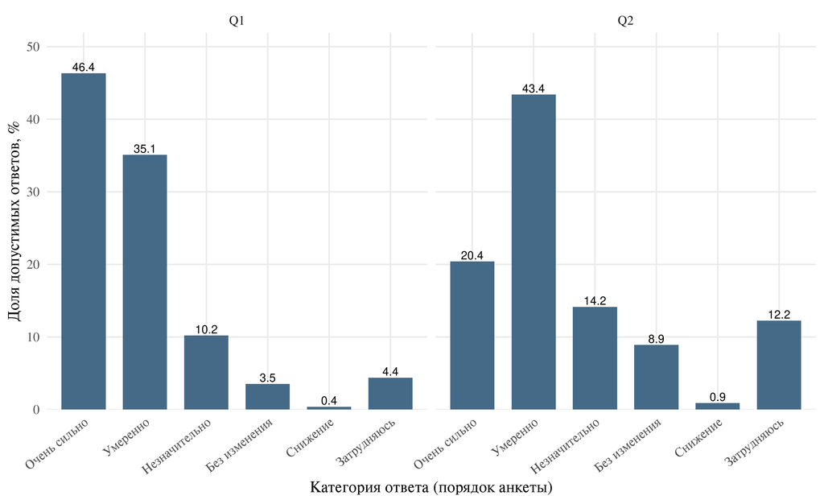

Рисунок 1. Изменение цен за прошлый (Q1) и следующий (Q2) месяц, % допустимых ответов.

## 9.2. Направление изменения цен за год

На рисунке 2 первые три столбца означают рост быстрее, так же или медленнее относительно сравниваемого периода. «Без изменения», «снижение» и «затрудняюсь» показаны раздельно; в Q3 частота снижения равна нулю. Это распределение направлений, не числовая инфляция.

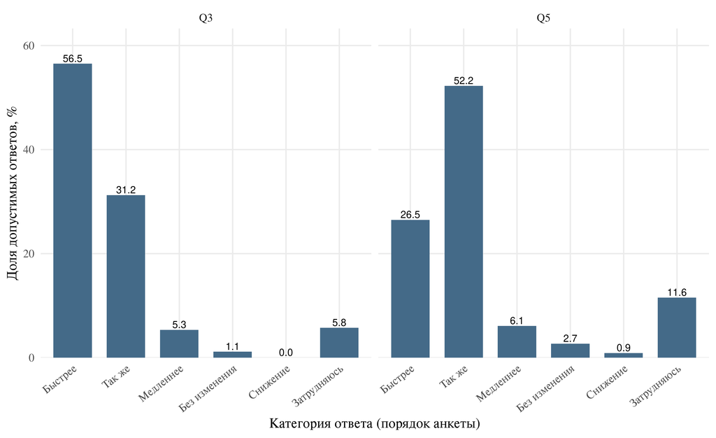

Рисунок 2. Q3: изменение цен за прошлый год; Q5: ожидания на следующий год, % допустимых ответов.

## 9.3. Числовые оценки инфляции

Рисунок 3 использует числовую ось X и все 13 кодов. Нулевая частота кода −5 в наблюдаемой инфляции сохраняется. Линии обозначают обычную и уточненную медианы, а не средние значения. Расстояния между кодами отражают различную ширину исходных интервалов.

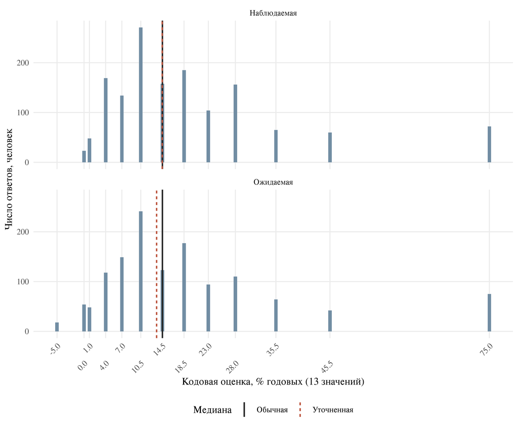

Рисунок 3. Частоты 13 кодовых значений наблюдаемой и ожидаемой инфляции; линии обычных и уточненных медиан.

## 9.4. Распределение дохода

Рисунок 4 построен для пригодных y_i. Шаг группировки - 5000 руб., высоты столбцов - абсолютные частоты. Вертикальная линия показывает обычную медиану дохода.

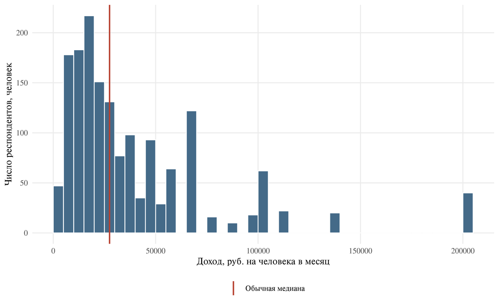

Рисунок 4. Доход на человека в месяц: гистограмма с шагом 5000 руб. и обычная медиана.

## 9.5. Частные индексы

На рисунке 5 обозначения I1–I5 соответствуют Q7–Q11. Штриховая линия 100 - равенство долей положительных и отрицательных ответов.

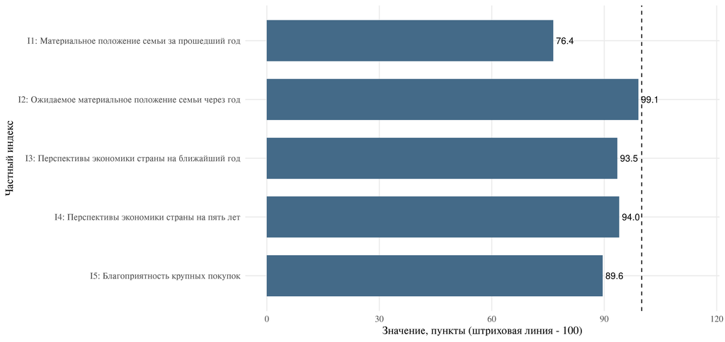

Рисунок 5. Пять частных потребительских индексов с полными названиями, пункты; линия 100 - баланс оценок.

## 9.6. Составные индексы

Рисунок 6 сопоставляет текущее состояние, ожидания и общий показатель настроений. Единицы всех трех столбцов - пункты индекса.

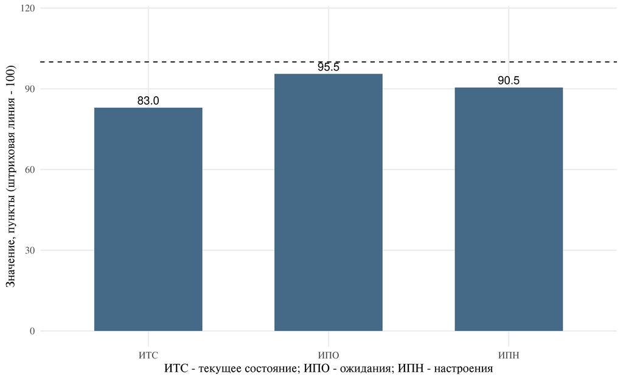

Рисунок 6. ИТС, ИПО и ИПН, пункты; штриховая линия 100 - баланс положительных и отрицательных оценок.

## 9.7. Исторические медианы и учебная точка

На рисунке 7 линии и круглые точки показывают опубликованные медианы января–августа 2026 года; треугольники — синтетический сентябрь. Сентябрьские точки не соединены с официальной историей. Ось Y — проценты годовых; числовые подписи исходного отчета приведены в таблице истории.

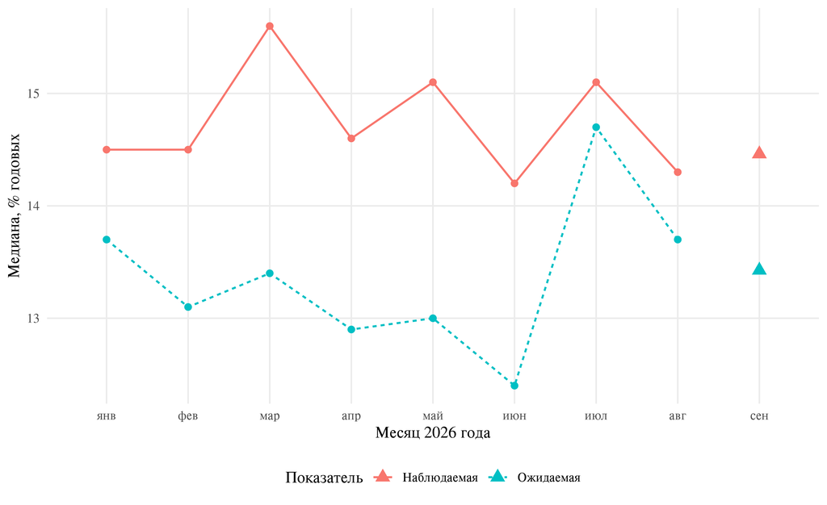

Рисунок 7. Медианы инфляции, % годовых: линии и круги — опубликованный январь–август; треугольники — учебный сентябрь.

## 9.8. Исторические индексы и учебные точки

Рисунок 8 показывает официальные ИТС, ИПО и ИПН за январь–август 2026 года линиями и круглыми точками. Учебные сентябрьские значения обозначены треугольниками без соединения с историческими линиями. Единицы измерения — пункты индекса.

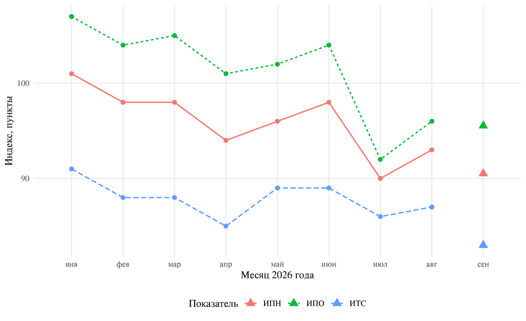

Рисунок 8. ИТС, ИПО, ИПН, пункты: линии и круги — опубликованный январь–август; треугольники — учебный сентябрь.

# 10. Исторический ряд и динамика август → сентябрь

Для каждой точки в расчетной таблице указан календарный период и источник. Официальная история перенесена из числовых подписей на рисунках 6 и 12 предоставленного PDF «Измерение инфляционных ожиданий и потребительских настроений», август 2026 года, волна 162 (с. 10 и 14). Дата получения и проверки — 18.10.2026. Инфляционные медианы опубликованы с одним десятичным знаком, индексы — целыми пунктами. Приложенная CSV-таблица и файл SOURCE_NOTES.txt фиксируют происхождение данных. Опубликованный ИПН используется непосредственно: пересчет по уже округленным ИТС и ИПО может дать другое число.

Таблица 40. Помесячные уровни и источник: официальные уровни и учебный сентябрь

| Период | obs | exp | ITS | IPO | IPN | Источник |
| --- | --- | --- | --- | --- | --- | --- |
| 2026-01 | 14.5 | 13.7 | 91 | 107.0 | 101.0 | Опубликованный ряд |
| 2026-02 | 14.5 | 13.1 | 88 | 104.0 | 98.0 | Опубликованный ряд |
| 2026-03 | 15.6 | 13.4 | 88 | 105.0 | 98.0 | Опубликованный ряд |
| 2026-04 | 14.6 | 12.9 | 85 | 101.0 | 94.0 | Опубликованный ряд |
| 2026-05 | 15.1 | 13.0 | 89 | 102.0 | 96.0 | Опубликованный ряд |
| 2026-06 | 14.2 | 12.4 | 89 | 104.0 | 98.0 | Опубликованный ряд |
| 2026-07 | 15.1 | 14.7 | 86 | 92.0 | 90.0 | Опубликованный ряд |
| 2026-08 | 14.3 | 13.7 | 87 | 96.0 | 93.0 | Опубликованный ряд |
| 2026-09 | 14.5 | 13.4 | 83 | 95.5 | 90.5 | Синтетическая выборка |

Таблица 41. Динамика август → учебный сентябрь: разность уровней

| Показатель | Август | Сентябрь | Разность | Единица | Статус |
| --- | --- | --- | --- | --- | --- |
| Наблюдаемая медиана | 14.3 | 14.5 | 0.2 | п. п. | Рассчитано |
| Ожидаемая медиана | 13.7 | 13.4 | -0.3 | п. п. | Рассчитано |
| ИТС | 87.0 | 83.0 | -4.0 | пункты | Рассчитано |
| ИПО | 96.0 | 95.5 | -0.5 | пункты | Рассчитано |
| ИПН | 93.0 | 90.5 | -2.5 | пункты | Рассчитано |

Уровни и изменения приведены в таблицах 40–41. Разность определяется как Δ = значение сентября − значение августа. Для медиан единица разности - **процентный пункт**, для индексов - **пункт индекса**. Относительный темп изменения не подменяет разность. При интерпретации учитывается опубликованная точность исходных уровней.

По учебному сентябрю наблюдаемая уточненная медиана (14,5%) выше ожидаемой (13,4%) на 1,0 п. п. По сравнению с опубликованным августом наблюдаемая медиана изменилась на +0,2 п. п., ожидаемая — на -0,3 п. п. ИТС изменился на -4,0, ИПО — на -0,5, ИПН — на -2,5 пункта.

Изменения ИТС и ИПО направлены одинаково. В сентябрьском учебном расчете ИТС = 83,0, ИПО = 95,5, ИПН = 90,5 пункта; все ниже 100, то есть отрицательные оценки в среднем преобладают. ИПО выше ИТС: ожидания относительно благоприятнее текущих оценок. Разности вычислены без промежуточного округления учебных показателей, но точность официальных уровней ограничена подписями публикации. Малым разностям, особенно меньше одного пункта индекса, нельзя приписывать избыточную точность.

**Различия между опубликованным августом и синтетическим сентябрем нельзя трактовать как реальный сдвиг настроений населения или как статистически установленное изменение.** Источники и методики различаются, синтетическая выборка не позволяет распространять выводы на население РФ.

# 11. Выводы

1. Проверены 2000 анкет: идентификаторы уникальны, размер семьи - положительное целое число, условные пропуски Q4/Q6 и работодателя согласованы с логикой опроса. Вместо восьми характеристик имеется семь; отсутствие доходной характеристики отражено как ограничение структуры. Для групповых сравнений введены пять квантильных групп расчетного дохода.
2. Обычные медианы обеих инфляционных переменных равны 14,5%; уточненные - 14,5 и 13,4% годовых. Различие обычных и уточненных оценок объясняется частотами и интерполяцией внутри медианного интервала, а не дополнительной точностью исходных ответов.
3. Доход рассчитан по 1613 анкетам. Обычная медиана - 27500,0 руб., уточненная при шаге 5000 руб. - 26164,1 руб., IQR - 33750,0 руб. Эти величины являются учебными оценками по кодированным интервалам.
4. ИТС = 83,0, ИПО = 95,5, ИПН = 90,5 пункта. Положительные ответы в среднем уступают отрицательным; ожидания относительно благоприятнее оценок текущего состояния. ИПН независимо проверен по двум формулам.
5. Групповые таблицы показывают распределения Q5 и медианы по доходу, а также ИПН по полу с явными основаниями. Они не устанавливают причинных связей и не являются статистическими выводами о населении.
6. Исторический ряд за январь–август 2026 года заполнен по предоставленной публикации; построены временные линии и отдельные учебные точки сентября, рассчитаны разности август → сентябрь. Официальные уровни за август: 14,3% и 13,7% для двух медиан, ИТС 87, ИПО 96, ИПН 93 пункта. Источник и точность зафиксированы; различия с синтетическими результатами являются только учебным сопоставлением.

# 12. Библиография

1. Методические указания к лабораторной работе №1 «Обработка анкет и описательная статистика в R: инфляционные ожидания и потребительские настроения». НИЯУ МИФИ. Москва, 2026. Предоставленный DOCX.
2. Индивидуальные синтетические данные: variant95.xlsx, лист «Анкеты».
3. ООО «инФОМ». Измерение инфляционных ожиданий и потребительских настроений на основе опросов населения. Август 2026, волна 162. Предоставленный PDF inFOM_26-08.pdf: с. 10, рис. 6; с. 14, рис. 12; с. 20, рис. 16; методические комментарии с. 74–78. Получен и проверен 18.10.2026. URL из методички: https://www.cbr.ru/Collection/Collection/File/62282/inFOM_26-08.pdf. Точность: медианы 0,1 п. п., индексы 1 пункт.
4. Банк России. Инфляционные ожидания и потребительские настроения. https://www.cbr.ru/analytics/dkp/inflationary_expectations/. Исторические значения проверены по предоставленному PDF отчета 18.10.2026.